# Gustavo Diaz – nu1

## Improving List Experiments

**Gustavo Diaz**  
McMaster University  
[gustavodiaz.org](https://gustavodiaz.org/)  
diazg2@mcmaster.ca

Slides: [gustavodiaz.org/nu](https://gustavodiaz.org/nu.html)

## Questions

- Have you lied about having COVID symptoms?
- Would you bribe a police officer to avoid a traffic ticket?
- Have you been offered goods or favors for your vote?
- Do you know anyone with ties to a militant organization?
- Would you oppose a black family moving next door?
- Would you allow Muslim immigrants to become citizens?

## What do these have in common?

- They are **sensitive questions**
- We can only learn about them using surveys
- **But** asking about them directly leads to **misreporting**
- This form of measurement error is called **sensitivity bias**

## Techniques to reduce sensitivity bias

- Honesty appeals
- Confidentiality protocols
- Randomized response
- Network scale-up
- Endorsement experiments
- List experiments

## Techniques to reduce sensitivity bias

- Honesty appeals
- Confidentiality protocols
- Randomized response
- Network scale-up
- Endorsement experiments
- **List experiments**

## Example

[figure not shown]

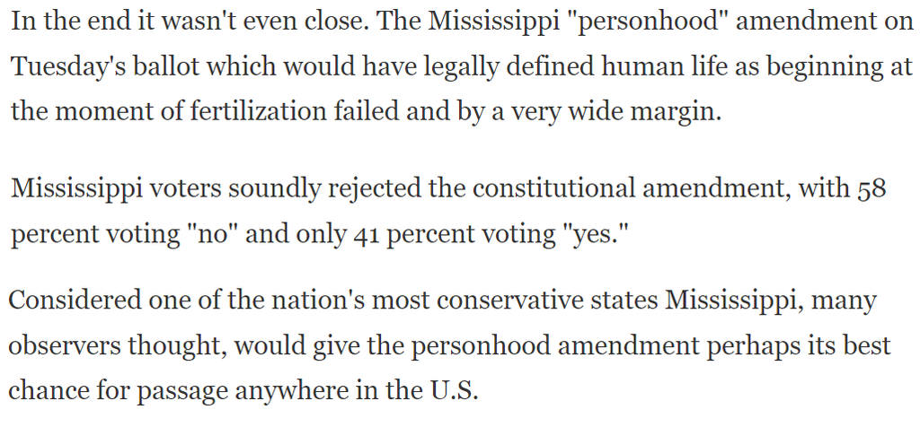

Source: [NPR](https://www.npr.org/sections/itsallpolitics/2011/11/08/142159280/mississippi-voters-reject-personhood-amendment)

## List experiment

Here is a list of things that some people have done.

Source: [Rosenfeld et al (2016)](https://doi.org/10.1111/ajps.12205)

## List experiment

Please listen to them and then tell me HOW MANY of them you have done in the past two years.

Source: [Rosenfeld et al (2016)](https://doi.org/10.1111/ajps.12205)

## List experiment

Do not tell me which ones. Just tell me HOW MANY:

### Control group

1. Discussed politics with family or friends
2. Cast a ballot for governor Phil Bryant
3. Paid dues to a union
4. Given money to a Tea Party candidate

Source: [Rosenfeld et al (2016)](https://doi.org/10.1111/ajps.12205)

## List experiment

Do not tell me which ones. Just tell me HOW MANY:

### Treatment group

1. Discussed politics with family or friends
2. Cast a ballot for governor Phil Bryant
3. Paid dues to a union
4. Given money to a Tea Party candidate

Source: [Rosenfeld et al (2016)](https://doi.org/10.1111/ajps.12205)

## List experiment

Do not tell me which ones. Just tell me HOW MANY:

### Treatment group

1. Discussed politics with family or friends
2. Cast a ballot for governor Phil Bryant
3. Paid dues to a union
4. Given money to a Tea Party candidate
5. **Voted “YES” on the Personhood Initiative**

Source: [Rosenfeld et al (2016)](https://doi.org/10.1111/ajps.12205)

## Prevalence rate

$$\text{Proportion(Voted yes)} =\\ \text{Mean(List with sensitive item)} -\\ \text{Mean(List without sensitive item)}$$

```r
library(estimatr)
difference_in_means(count ~ sensitive, data = df)
```

We get a **prevalence rate estimate** but we **do not know** how individual respondents voted!

## Compare with direct question

Did you vote YES or NO on the Personhood Initiative, which appeared on the November 2011 Mississippi General Election Ballot?

$$\text{Proportion(Voted yes)} =\\ \text{Mean(Answer yes)}$$

```r
t.test(yes ~ 1, data = df)
```

## Validation

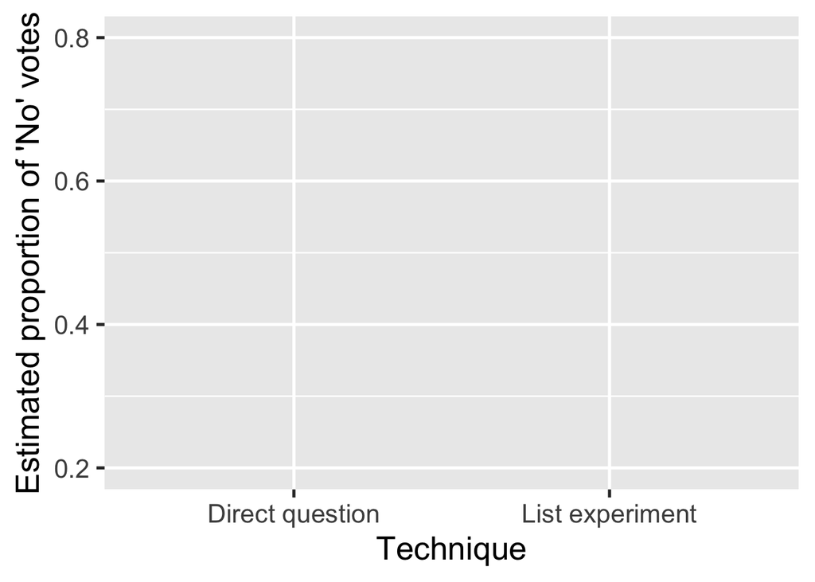

Adapted from [Rosenfeld et al (2016)](https://doi.org/10.1111/ajps.12205)

## Validation

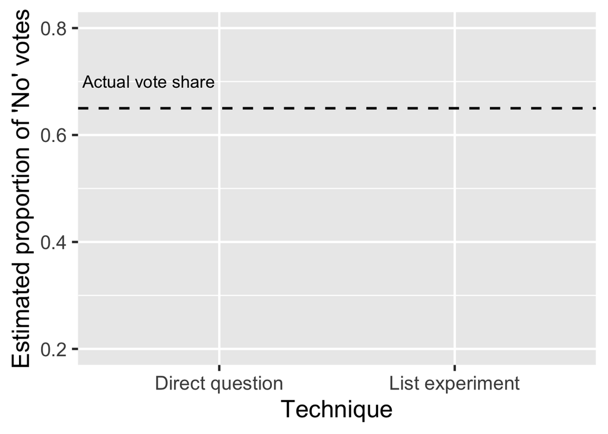

Adapted from [Rosenfeld et al (2016)](https://doi.org/10.1111/ajps.12205)

## Validation

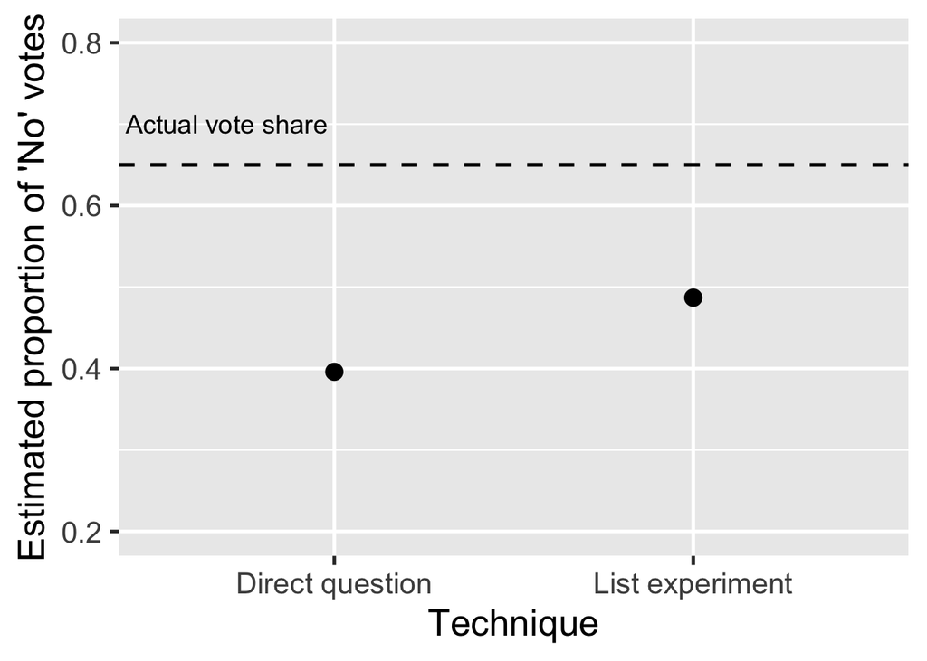

Adapted from [Rosenfeld et al (2016)](https://doi.org/10.1111/ajps.12205)

## Validation

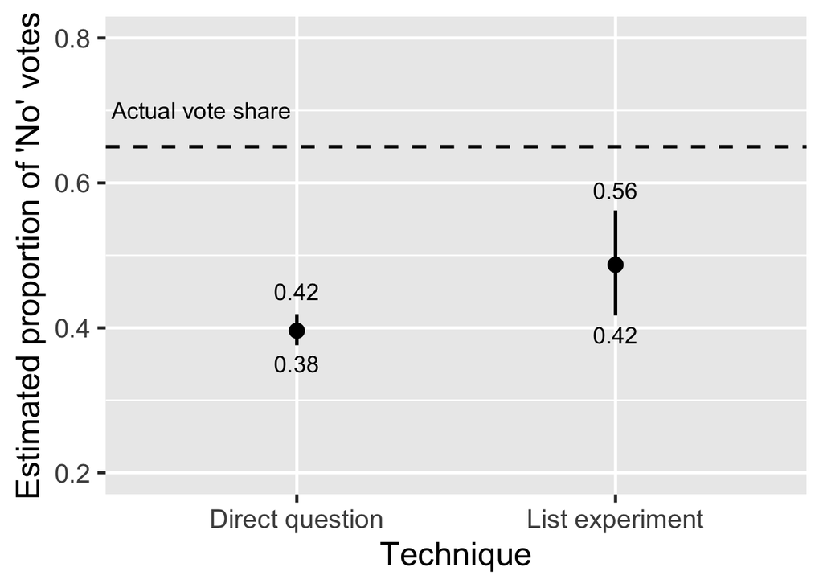

Adapted from [Rosenfeld et al (2016)](https://doi.org/10.1111/ajps.12205)

## Sensitivity bias reduction not always worth the increased variance

## Can we do better?

## Double list experiment

**List A**

- Californians for Disability (advocating for people with disabilities)
- California National Organization for Women (advocating for women’s equality and empowerment)
- American Family Association (advocating for pro-family values)
- American Red Cross (humanitarian organization)

**List B**

- American Legion (veterans service organization)
- Equality California (gay and lesbian advocacy organization)
- Tea Party Patriots (conservative group supporting lower taxes and limited government)
- Salvation Army (charitable organization)

Source: [Alvarez et al (2019)](https://doi.org/10.1017/pan.2018.57)

## Sensitive item

**Organization X (advocating for immigration reduction and measures against undocumented immigration)**

- Everyone sees it
- Randomly appears in list A or B
- Equivalent to two parallel list experiments

## Three prevalence estimators

$$\hat{\tau}_A = \text{Mean}(A_t) - \text{Mean}(A_c)$$

```r
difference_in_means(count ~ sensitive, subset = list == "A", data = df)
```

$$\hat{\tau}_B = \text{Mean}(B_t) - \text{Mean}(B_c)$$

```r
difference_in_means(count ~ sensitive, subset = list == "B", data = df )
```

$$\hat{\tau}_{Pooled} = (\hat{\tau}_A + \hat{\tau}_B)/2$$

```r
lm_robust(count ~ sensitive + list, clusters = id, data = df)
```

See [Diaz (2023)](https://doi.org/10.1017/XPS.2023.24) and [Miller (1984)](https://www.proquest.com/docview/303296717) for details

## DLE yields more precise estimates

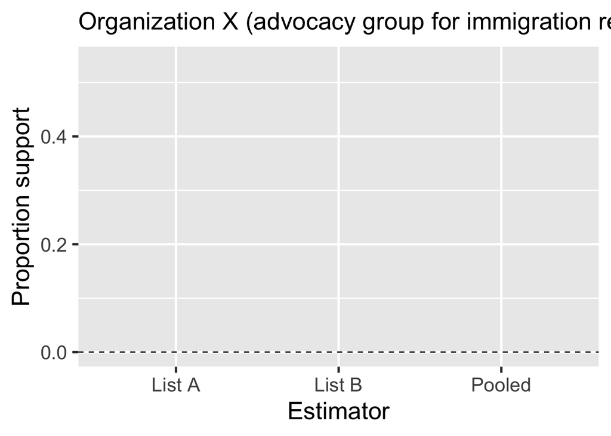

Adapted from [Diaz (2023)](https://doi.org/10.1017/XPS.2023.24)

## DLE yields more precise estimates

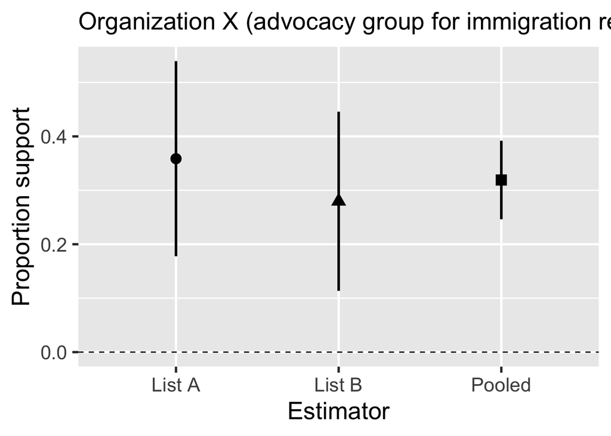

Adapted from [Diaz (2023)](https://doi.org/10.1017/XPS.2023.24)

## But variance reduction is not free

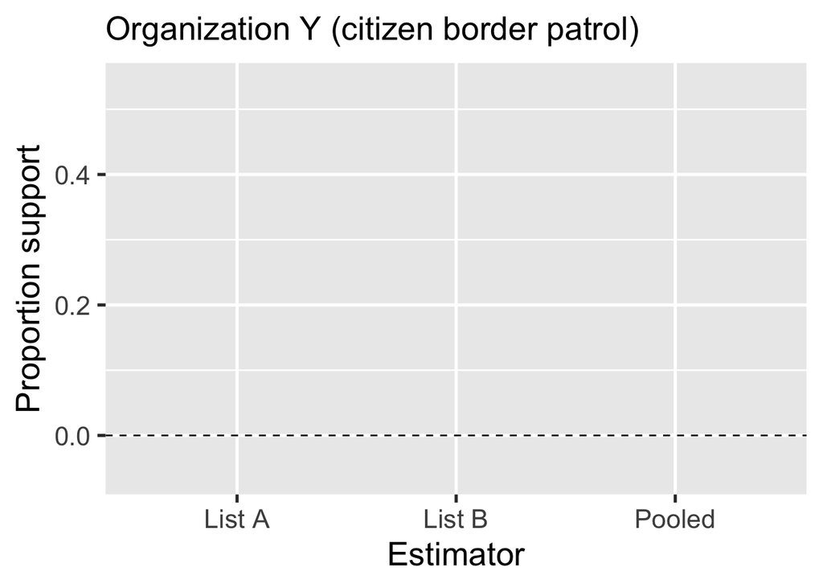

Adapted from [Diaz (2023)](https://doi.org/10.1017/XPS.2023.24)

## But variance reduction is not free

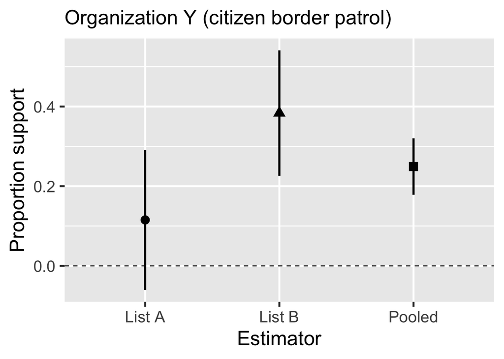

Adapted from [Diaz (2023)](https://doi.org/10.1017/XPS.2023.24)

## Carryover design effects

**Design effect [(Blair and Imai 2012)](https://doi.org/10.1093/pan/mpr048)**

The inclusion of a sensitive item affects how survey participants respond to the baseline items **within the list**.

**Carryover design effect**

The inclusion of a sensitive item **in one list** affects how participants respond to the baseline items in **the other list**.

## Why does this happen?

- Unique question format
- Lists usually appear close to each other
- Positive correlation across lists [(Glynn 2013)](https://doi.org/10.1093/poq/nfs070)

## DLE variants

| List order | Sensitive item location |
| --- | --- |
| Fixed | Fixed |
| Randomized | Fixed |
| Fixed | Randomized |
| Randomized | Randomized |

## DLE variants

| List order | Sensitive item location |
| --- | --- |
| Fixed | Fixed |
| Randomized | Fixed |
| Fixed | Randomized |
| Randomized | Randomized |

- **Fixed-fixed** is *not* an admissible design

## DLE variants

| List order | Sensitive item location |
| --- | --- |
| Fixed | Fixed |
| Randomized | Fixed |
| Fixed | Randomized |
| Randomized | Randomized |

- **Fixed-fixed** is *not* an admissible design
- **Randomized-fixed** keeps sensitive item in second list

## DLE variants

| List order | Sensitive item location |
| --- | --- |
| Fixed | Fixed |
| Randomized | Fixed |
| Fixed | Randomized |
| Randomized | Randomized |

- **Fixed-fixed** is *not* an admissible design
- **Randomized-fixed** keeps sensitive item in second list

## DLE variants

| List order | Sensitive item location |
| --- | --- |
| Fixed | Fixed |
| Randomized | Fixed |
| Fixed | Randomized |
| Randomized | Randomized |

- **Fixed-fixed** is *not* an admissible design
- **Randomized-fixed** keeps sensitive item in second list
- **Fixed-randomized** and **randomized-randomized** *shuffle sensitive item order*

## Asymmetric shift

| Observed response | List 1 | List 2 | Difference |
| --- | --- | --- | --- |
| Baseline | 2 | 2 | 0 |
| **Deflation** |  |  |  |
| Sensitive first | 1 | 1 | 0 |
| Sensitive second | 2 | 1 | 1 |
| **Inflation** |  |  |  |
| Sensitive first | 3 | 3 | 0 |
| Sensitive second | 2 | 3 | -1 |

## Asymmetric shift

| Observed response | List 1 | List 2 | Difference |
| --- | --- | --- | --- |
| Baseline | 2 | 2 | 0 |
| **Deflation** |  |  |  |
| Sensitive first | 1 | 1 | 0 |
| Sensitive second | 2 | 1 | 1 |
| **Inflation** |  |  |  |
| Sensitive first | 3 | 3 | 0 |
| Sensitive second | 2 | 3 | -1 |

## Asymmetric shift

| Observed response | List 1 | List 2 | Difference |
| --- | --- | --- | --- |
| Baseline | 2 | 2 | 0 |
| **Deflation** |  |  |  |
| Sensitive first | 1 | 1 | 0 |
| Sensitive second | 2 | 1 | 1 |
| **Inflation** |  |  |  |
| Sensitive first | 3 | 3 | 0 |
| Sensitive second | 2 | 3 | -1 |

## Asymmetric shift

| Observed response | List 1 | List 2 | Difference |
| --- | --- | --- | --- |
| Baseline | 2 | 2 | 0 |
| **Deflation** |  |  |  |
| Sensitive first | 1 | 1 | 0 |
| Sensitive second | 2 | 1 | 1 |
| **Inflation** |  |  |  |
| Sensitive first | 3 | 3 | 0 |
| Sensitive second | 2 | 3 | -1 |

## Asymmetric shift

| Observed response | List 1 | List 2 | Difference |
| --- | --- | --- | --- |
| Baseline | 2 | 2 | 0 |
| **Deflation** |  |  |  |
| Sensitive first | 1 | 1 | 0 |
| Sensitive second | 2 | 1 | 1 |
| **Inflation** |  |  |  |
| Sensitive first | 3 | 3 | 0 |
| Sensitive second | 2 | 3 | -1 |

## Asymmetric shift

| Observed response | List 1 | List 2 | Difference |
| --- | --- | --- | --- |
| Baseline | 2 | 2 | 0 |
| **Deflation** |  |  |  |
| Sensitive first | 1 | 1 | 0 |
| Sensitive second | 2 | 1 | 1 |
| **Inflation** |  |  |  |
| Sensitive first | 3 | 3 | 0 |
| Sensitive second | 2 | 3 | -1 |

## Asymmetric shift

| Observed response | List 1 | List 2 | Difference |
| --- | --- | --- | --- |
| Baseline | 2 | 2 | 0 |
| **Deflation** |  |  |  |
| Sensitive first | 1 | 1 | 0 |
| Sensitive second | 2 | 1 | 1 |
| **Inflation** |  |  |  |
| Sensitive first | 3 | 3 | 0 |
| Sensitive second | 2 | 3 | -1 |

## Asymmetric shift

| Observed response | List 1 | List 2 | Difference |
| --- | --- | --- | --- |
| Baseline | 2 | 2 | 0 |
| **Deflation** |  |  |  |
| Sensitive first | 1 | 1 | 0 |
| Sensitive second | 2 | 1 | 1 |
| **Inflation** |  |  |  |
| Sensitive first | 3 | 3 | 0 |
| Sensitive second | 2 | 3 | -1 |

## Difference-in-differences test

$$\hat{\tau}_1 = \text{Mean}(\text{First list}_t) - \text{Mean}(\text{First list}_c)$$

$$\hat{\tau}_2 = \text{Mean}(\text{Second list}_t) - \text{Mean}(\text{Second list}_c)$$

- $H_0: \hat{\tau}_1 - \hat{\tau}_2 = 0$
- **Deflation:** $\hat{\tau}_1 - \hat{\tau}_2 < 0$
- **Inflation:** $\hat{\tau}_1 - \hat{\tau}_2 > 0$

```r
# For fixed-randomized design
lm_robust(count ~ sensitive*first, clusters = id, data = df)
```

There is also a signed-rank test [(Diaz 2023)](https://doi.org/10.1017/XPS.2023.24)

## Application to [Alvarez et al (2019)](https://doi.org/10.1017/pan.2018.57)

| Experiment | Statistic | p-value |
| --- | --- | --- |
| Organization X (advocacy group) | 0.079 | 0.623 |
| Organization Y (border patrol) | -0.268 | 0.082 |

## Application to [Alvarez et al (2019)](https://doi.org/10.1017/pan.2018.57)

| Experiment | Statistic | p-value |
| --- | --- | --- |
| Organization X (advocacy group) | 0.079 | 0.623 |
| Organization Y (border patrol) | -0.268 | 0.082 |

## Application to [Alvarez et al (2019)](https://doi.org/10.1017/pan.2018.57)

| Experiment | Statistic | p-value |
| --- | --- | --- |
| Organization X (advocacy group) | 0.079 | 0.623 |
| Organization Y (border patrol) | -0.268 | 0.082 |

## Tests improve our ability to choose baseline items for a DLE

## They also help when other things go wrong

## Criminal governance tools in Uruguay

- Facebook sample of Montevideo residents `(N = 2688)`
- Four criminal governance strategies

### Violent

- Threaten neighbors
- Evict neighbors

### Non-violent

- Make donations to neighbors
- Offer work to neighbors

Work in progres with [Ines Fynn](https://uy.linkedin.com/in/ines-fynn-8b07733b), [Verónica Pérez Bentancur](https://cienciassociales.edu.uy/departamento-de-ciencia-politica/veronica-perez-bentancur/), and [Lucía Tiscornia](https://www.luciatiscornia.com/)

## Criminal governance tools in Uruguay

- Facebook sample of Montevideo residents `(N = 2688)`
- Four criminal governance strategies

### Violent

- **Threaten neighbors**
- Evict neighbors

### Non-violent

- Make donations to neighbors
- Offer work to neighbors

Work in progres with [Ines Fynn](https://uy.linkedin.com/in/ines-fynn-8b07733b), [Verónica Pérez Bentancur](https://cienciassociales.edu.uy/departamento-de-ciencia-politica/veronica-perez-bentancur/), and [Lucía Tiscornia](https://www.luciatiscornia.com/)

## DLE with placebo item

Things people have experienced in the last six months:

| List A | List B |
| --- | --- |
| Saw people doing sports | Saw people playing soccer |
| Visited friends | Chatted with friends |
| Activities by feminist groups | Activities by LGBTQ groups |
| Went to church | Went to charity events |

## DLE with placebo item

Things people have experienced in the last six months:

| List A | List B |
| --- | --- |
| Saw people doing sports | Saw people playing soccer |
| Visited friends | Chatted with friends |
| Activities by feminist groups | Activities by LGBTQ groups |
| Went to church | Went to charity events |
| Gangs threatening neighbors | Did not drink mate |

## DLE with placebo item

Things people have experienced in the last six months:

| List A | List B |
| --- | --- |
| Saw people doing sports | Saw people playing soccer |
| Visited friends | Chatted with friends |
| Activities by feminist groups | Activities by LGBTQ groups |
| Went to church | Went to charity events |
| Did not drink mate | Gangs threatening neighbors |

## Prevalence estimates

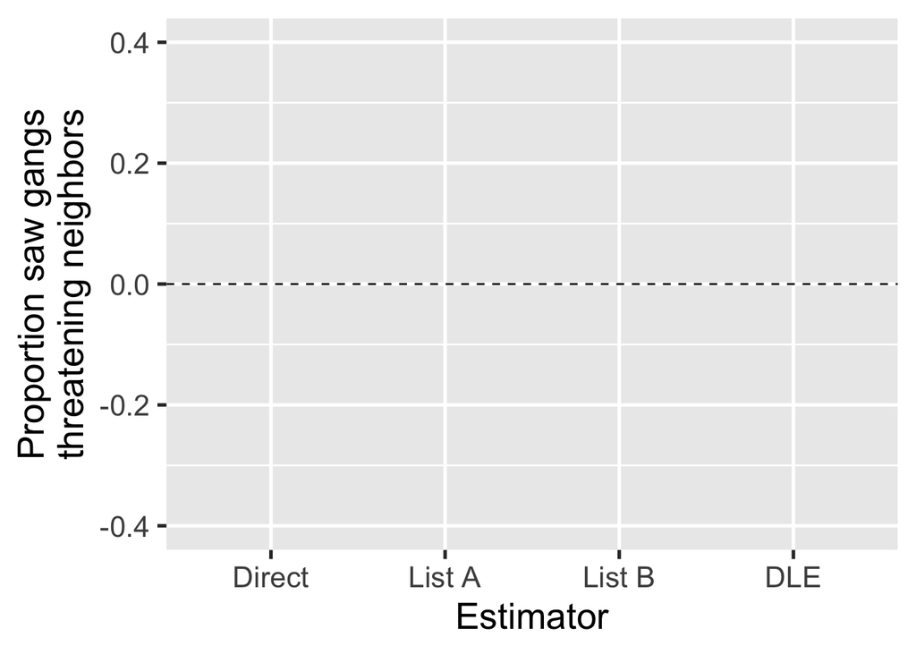

Looks the same for the other sensitive items!

## Prevalence estimates

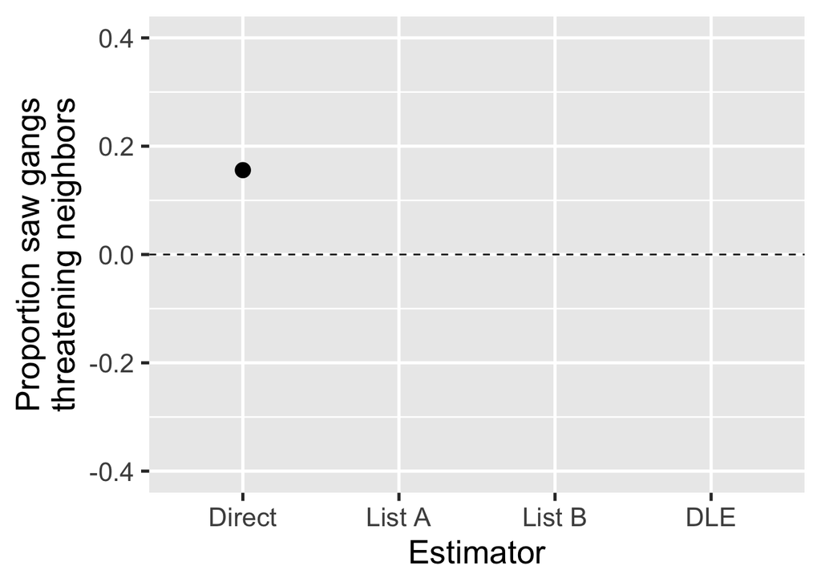

Looks the same for the other sensitive items!

## Prevalence estimates

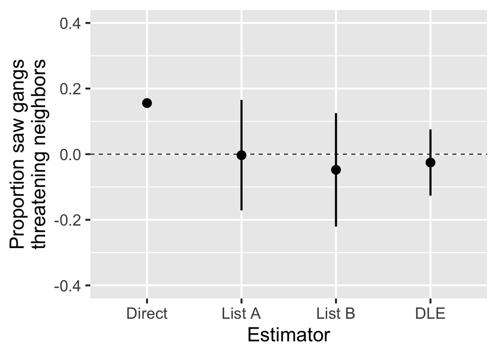

Looks the same for the other sensitive items!

## What went wrong?

- Placebo item more frequent than we anticipated
- Offsets prevalence rates we would have observed
- **Solution:** Reconstruct estimate bounds without placebo item
- **Challenge:** Respondents may have noticed sensitive item and altered responses in unintended ways
- Use tests to rule out **strategic errors**

## Applying difference-in-differences test

| Sensitive item | Statistic | p-value |
| --- | --- | --- |
| Threaten neighbors | 0.12 | 0.41 |
| Evict neighbors | 0.08 | 0.58 |
| Make donations | -0.24 | 0.16 |
| Offer work | -0.11 | 0.47 |

## Applying difference-in-differences test

| Sensitive item | Statistic | p-value |
| --- | --- | --- |
| Threaten neighbors | 0.12 | 0.41 |
| Evict neighbors | 0.08 | 0.58 |
| Make donations | -0.24 | 0.16 |
| Offer work | -0.11 | 0.47 |

Observed test statistics **not unlikely** under the null hypothesis of **no carryover design effect**

## So we can move from this

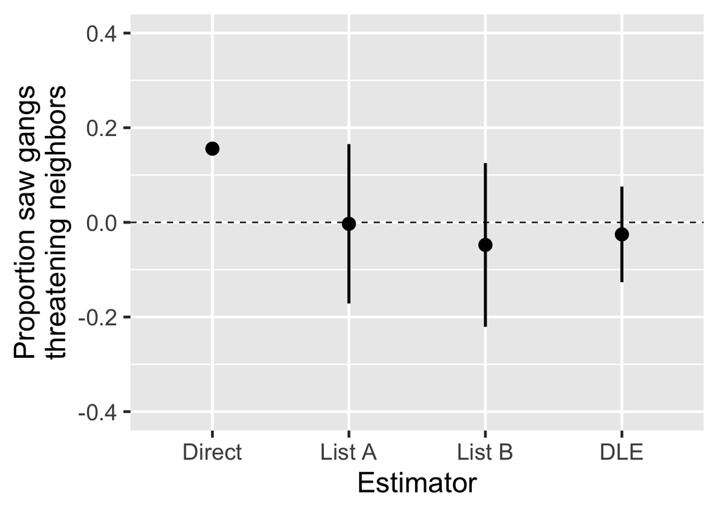

## To estimate bounds

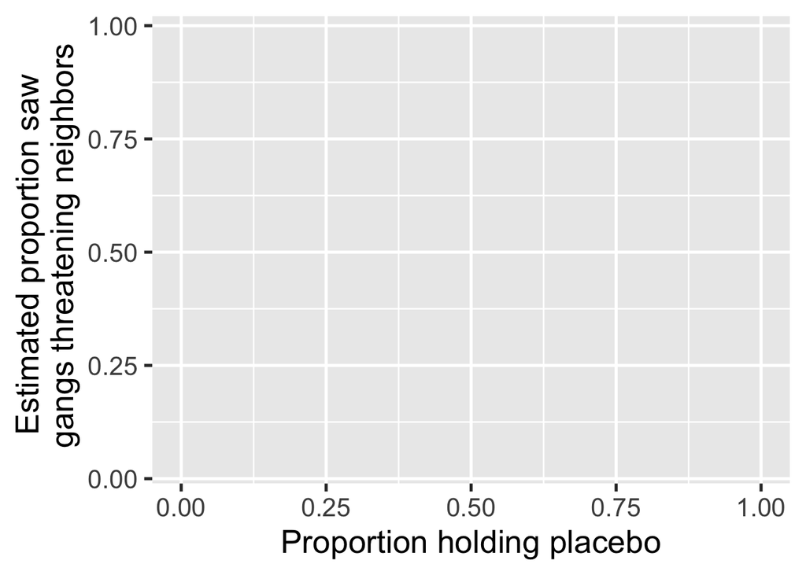

## To estimate bounds

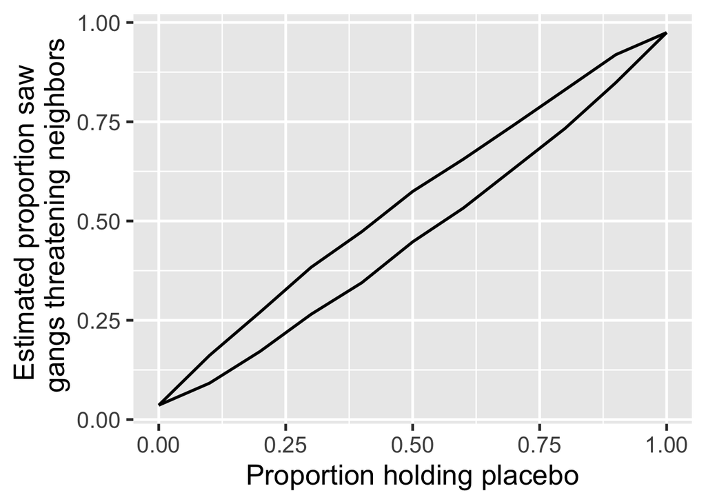

## To estimate bounds

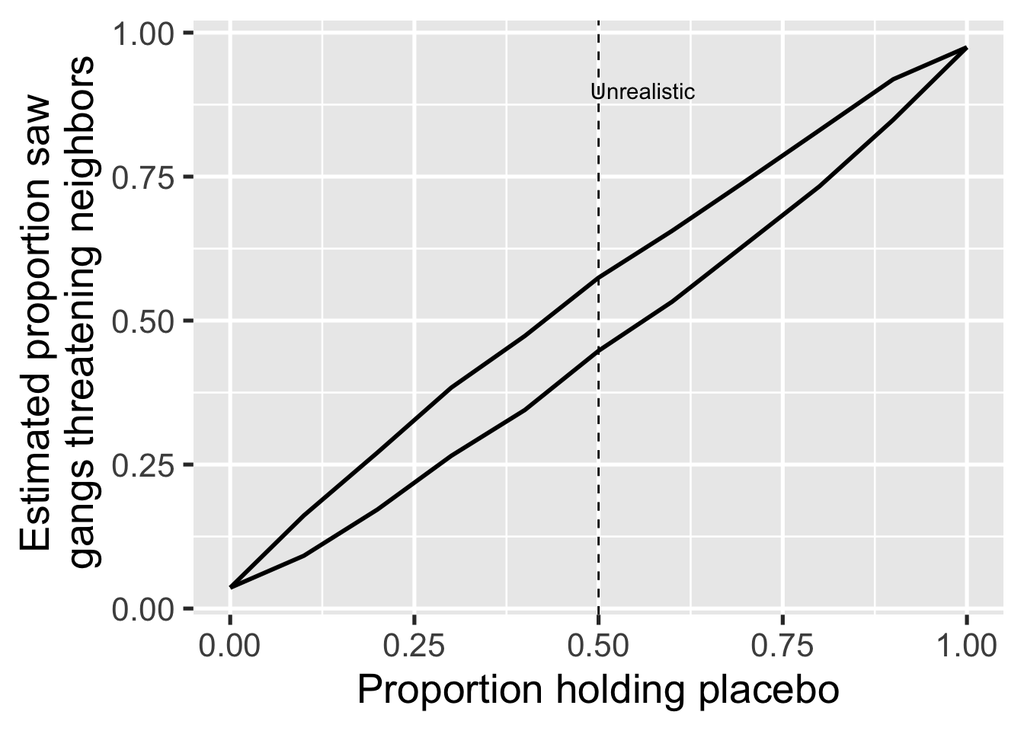

## To estimate bounds

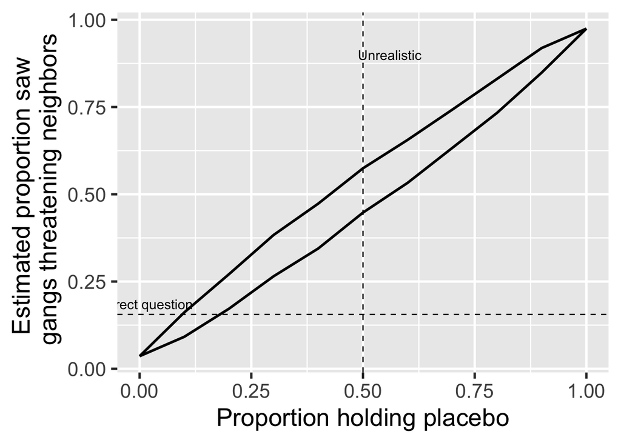

## Conclusion

### Summary

- DLEs improve along bias-variance frontier
- But bring additional questions about validity
- New tools to address validity
- Applications: Justify research design and recover estimates

**Learn more:** [gustavodiaz.org](https://gustavodiaz.org/)

## Conclusion

### Lessons

- Seemingly cost-free innovations may have hidden costs
- Need tools to incorporate into workflow
- Adaptive rules before confirmatory analyses

**Learn more:** [gustavodiaz.org](https://gustavodiaz.org/)

## Appendix

- Alvarez et al (2019) details
- Montevideo survey responses
- Signed rank test
- DLE cost simulations
- Performance simulations
- Placebo tests
- Network scale-up

## [Alvarez et al (2019)](https://doi.org/10.1017/pan.2018.57) details

|  | Placement List A | Placement List B |
| --- | --- | --- |
| **Sensitive item** |  |  |
| Organization X | 545 | 525 |
| Organization Y | 537 | 543 |

## Mean supported organizations

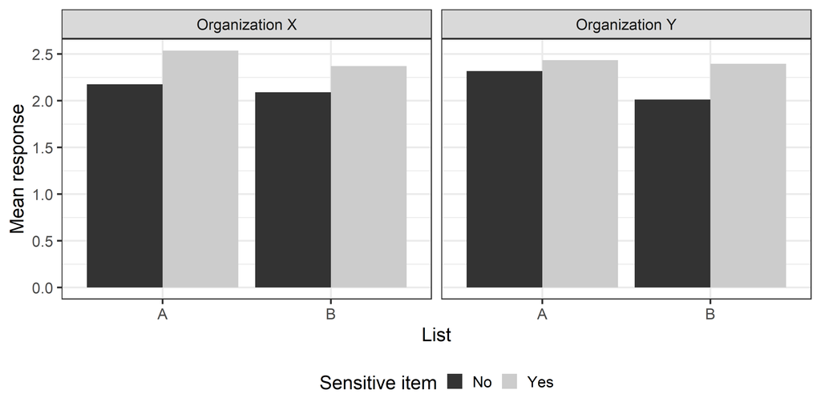

## Control list distributions

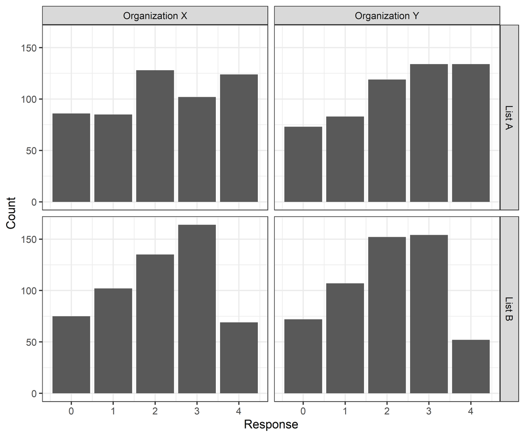

## Montevideo survey

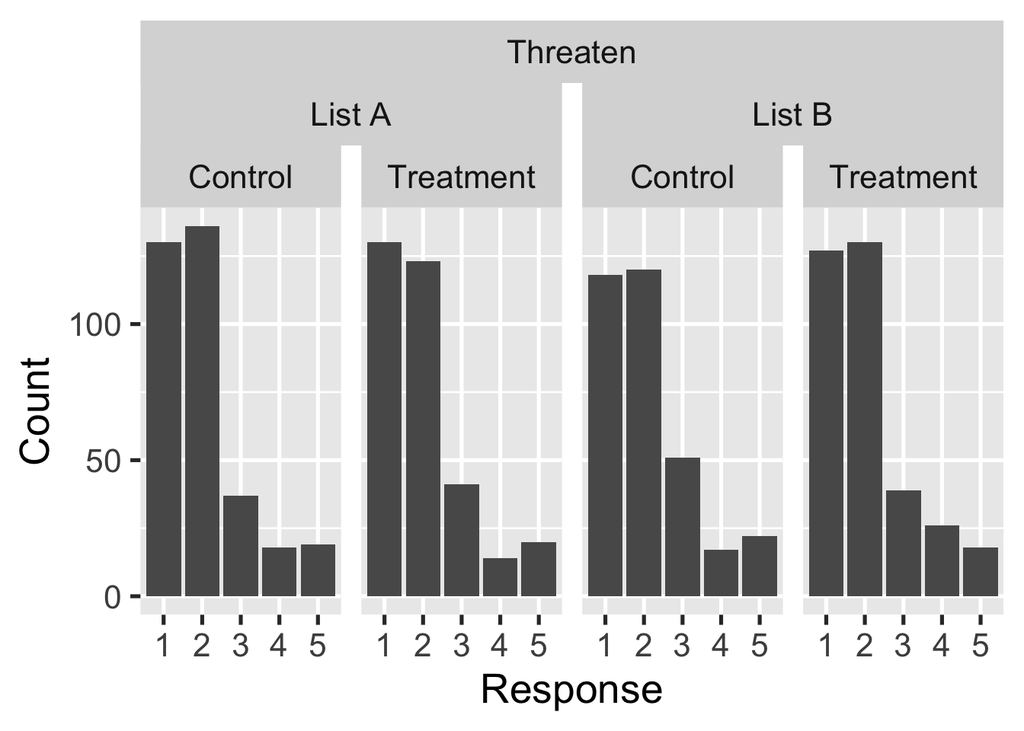

## Montevideo survey

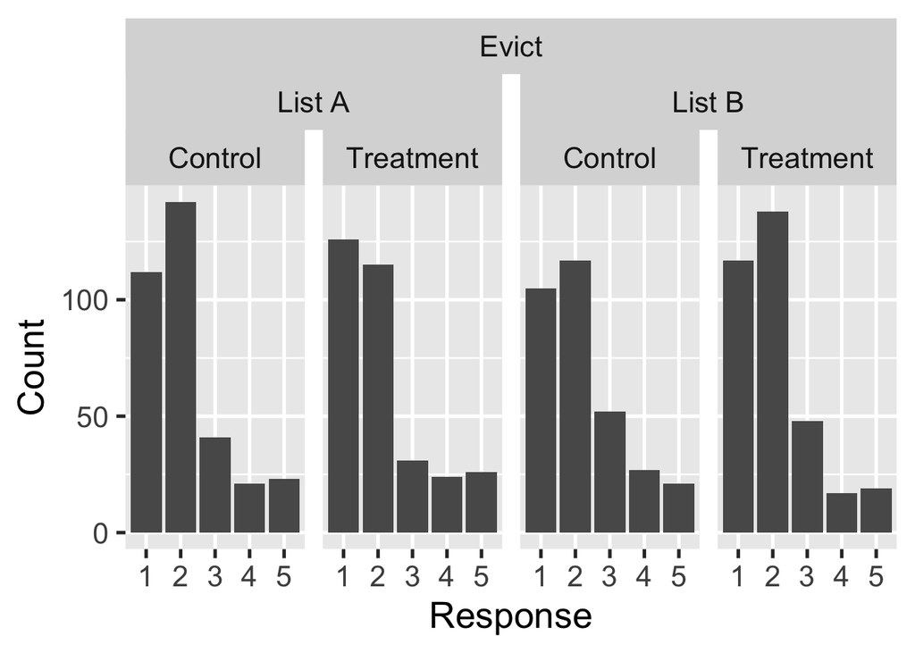

## Montevideo survey

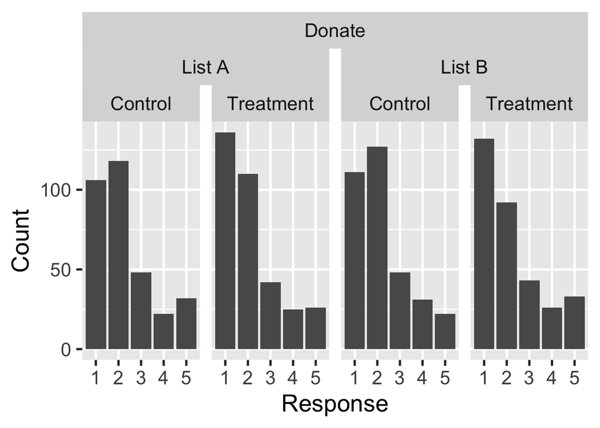

## Montevideo survey

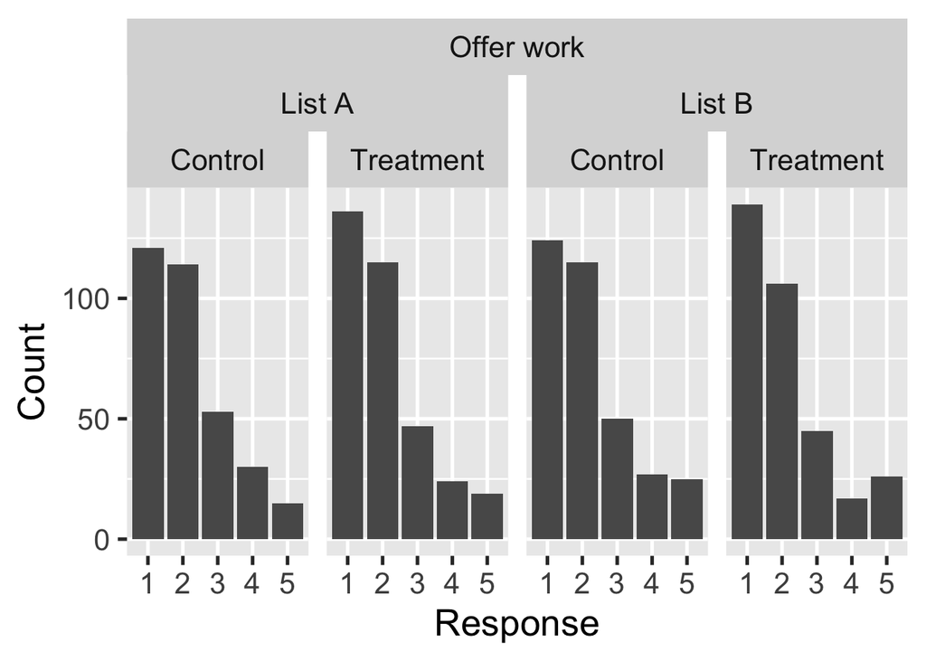

## Stephenson’s signed rank test

$$\widetilde{T} = \sum_{i=1}^N \text{sgn} \{(z_i - (1-z_i)) (Y_{i1} - Y_{i2})\} \times \tilde{q}_i$$

$$\tilde{q}_i = {q_i-1 \choose m-1} \text{ for } q_i \geq m$$

$$\tilde{q}_i = 0 \text{ for } q_i < m$$

$$\text{with } 1 \leq m \leq N$$

See [Stephenson (1981)](https://doi.org/10.1080/01621459.1981.10477749) and [Rosenbaum (2020)](https://mitpressbookstore.mit.edu/book/9783030464042) for details

## Applied to [Alvarez et al (2019)](https://doi.org/10.1017/pan.2018.57)

| m | Organization X Statistic | Organization X p-value | Organization Y Statistic | Organization Y p-value |
| --- | --- | --- | --- | --- |
| 2 | 8.356400e+04 | 1 | 3.571300e+04 | 1 |
| 5 | 3.809258e+12 | 1 | 3.323093e+12 | 1 |
| 10 | 1.791638e+23 | 1 | 1.825804e+23 | 1 |
| 50 | 1.439408e+86 | 1 | 2.533938e+86 | 1 |

## DLEs are costly to implement

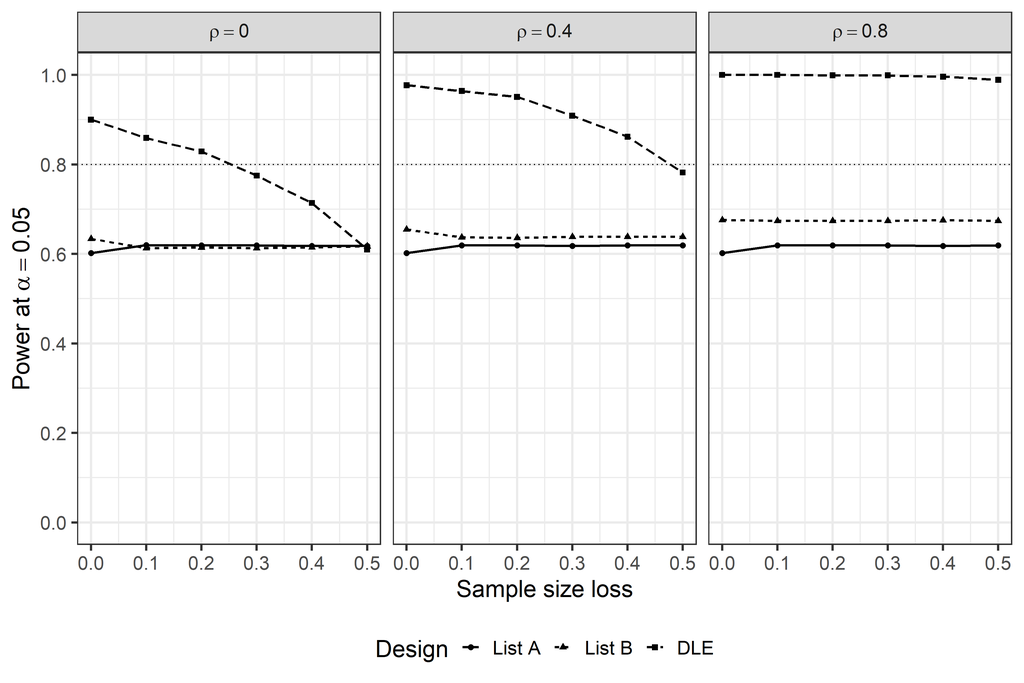

## Test performance

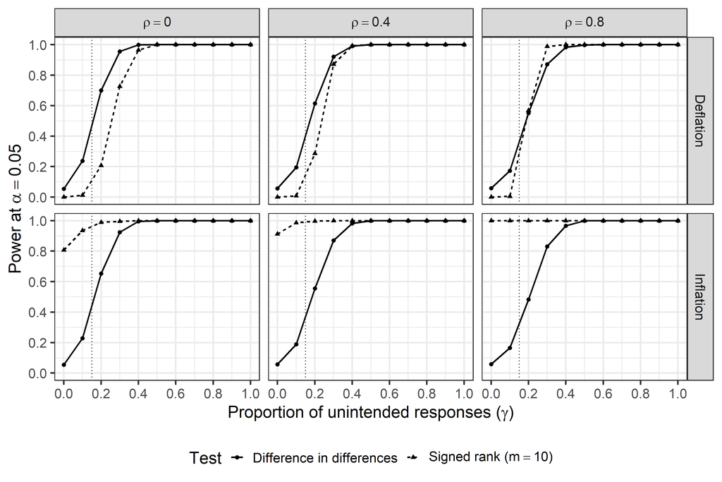

## Signed rank performance

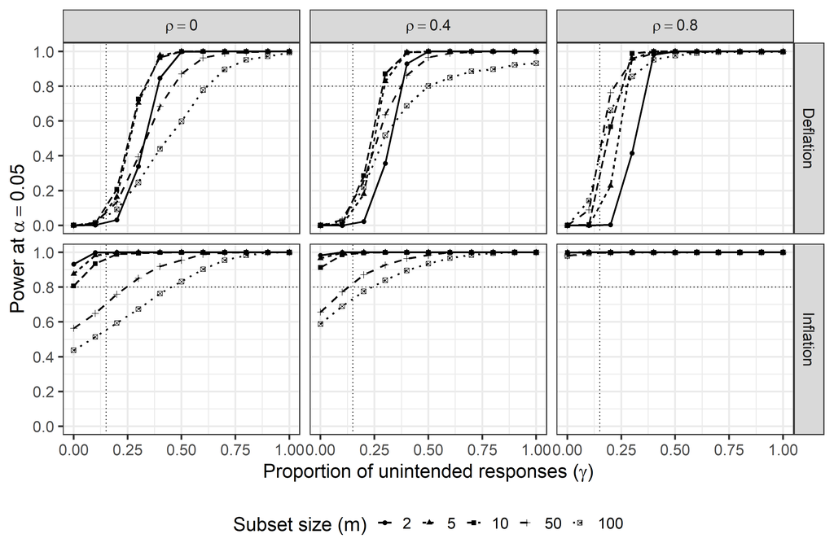

## Placebo tests

| Item | Placebo I Estimate | Placebo I p | Placebo I n | Placebo II Estimate | Placebo II p | Placebo II n |
| --- | --- | --- | --- | --- | --- | --- |
| Donate | 0.08 | 0.55 | 133 | -0.03 | 0.32 | 635 |
| Evict | 0.14 | 0.46 | 32 | 0.00 | 0.95 | 628 |
| Threaten | 0.24 | 0.08 | 102 | 0.02 | 0.44 | 641 |
| Work | 0.03 | 0.88 | 64 | 0.01 | 0.58 | 647 |

See [Aronow et al (2015)](https://doi.org/10.1093/jssam/smu023) for details

## Network scale-up method

**How many X do you know,**

## Network scale-up method

**How many X do you know, who also know you,**

## Network scale-up method

**How many X do you know, who also know you, with whom you have interacted in the last year**

## Network scale-up method

**How many X do you know, who also know you, with whom you have interacted in the last year in person, by phone, or any other channel?**

## Network scale-up method

**How many X do you know…**

From *Las Piedras*  
Male 25-29  
Police officers  
University students  
Had a kid last year  
Passed away last year  
Married last year  
Female 45-49

Public employees  
Welfare card holders  
Registered with party  
With kids in public school  
Did not vote in last election  
Currently in jail  
Recently unemployed  
*SENSITIVE ITEM*

## NSUM results

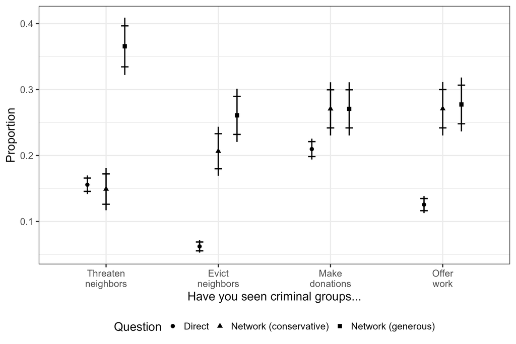